# A short introduction to the RAVE model

# Introduction

This post is a short introduction to the RAVE model proposed by the paper [RAVE: A variational autoencoder for fast and high-quality neural audio synthesis](https://www.google.com/url?q=https://arxiv.org/abs/2111.05011&sa=D&source=editors&ust=1763114472800316&usg=AOvVaw21BUva7PBXZD-a2FJ8Lf2p).

The RAVE model is a [variational autoencoder](https://www.google.com/url?q=https://docs.google.com/document/u/0/d/1bgsMYJV8xzBlf0J-lD0PKpuT3Ylt6hNZNji4Ydzc7t0/edit&sa=D&source=editors&ust=1763114472800486&usg=AOvVaw2pHyeMaeKDdHi_Iqx92dE-) trained in two stages:

- First the regular variational autoencoder training,
- Followed by an additional adversarial training stage for the decoder.

# Training

## Stage 1: Regular variational autoencoder training

For the reconstruction part, the RAVE paper proposes to use the spectral distance from the [DDSP: Differentiable Digital Signal Processing](https://www.google.com/url?q=https://arxiv.org/abs/2001.04643&sa=D&source=editors&ust=1763114472805885&usg=AOvVaw2seKAWLHiG5DyFNcA6nYfD) paper:

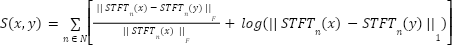

As explained in the RAVE paper, this amplitude spectrum-based distance does not penalize the model for inaccurately reconstructed phase, but encompasses important perceptual features about the signal.

## Notes about the phase

The spectral distance does not directly force the model to reproduce the phase of the input audio signal. However, the model is encouraged to produce plausible phase in two ways:

- The fact that the spectral distance is computed at multiple scales.
- The only way to reproduce the correct magnitude patterns across multiple STFT window sizes is to generate time-domain signals with realistic, coherent phase.
- The adversarial loss.
- The discriminator doesn’t directly evaluate the phase but it evaluates if the output signal is realistic.
- To fool the discriminator, the decoder must learn to produce phase-coherent signals because inconsistent or unnatural phase (e.g. “swishy”, “metallic”, “blurry” artifacts) would be easy to detect.

# Model architecture

## Encoder

|  | Type | Length | Dimension |
| --- | --- | --- | --- |
| Input | Raw audio waveform | 65536 samples | 16 (16-band decomposition) |
| Output | Latent vectors | 512 | 256 (128 mean + 128 variance) |

## Decoder

- The decoder of RAVE is composed of 1D transposed convolutions and residual connections.
- It produces outputs of the same length and dimension as the input.

# Implementation

## Encoder

- The encoder of the RAVE paper has the following architecture

|  | Length (temporal axis) |  | Stride | channels |  |
| --- | --- | --- | --- | --- | --- |
|  | Input | Output |  | Input | Output |
| Input | - | [65536](https://www.google.com/url?q=https://github.com/acids-ircam/RAVE/blob/v1/train_rave.py%23L57&sa=D&source=editors&ust=1763114472828422&usg=AOvVaw30CTN9KBd15D7um7RR-elp) | - | - | [16](https://www.google.com/url?q=https://github.com/acids-ircam/RAVE/blob/v1/train_rave.py%23L24&sa=D&source=editors&ust=1763114472828751&usg=AOvVaw2ZEmh2MR5kMEcODZ2JjTZO) |
| [Convolution 1](https://www.google.com/url?q=https://github.com/acids-ircam/RAVE/blob/v1/rave/model.py%23L304&sa=D&source=editors&ust=1763114472828906&usg=AOvVaw1qxyG6akml8-7yUdFAo3pQ) | 65536 | 65536 | [1](https://www.google.com/url?q=https://github.com/acids-ircam/RAVE/blob/v1/rave/model.py%23L304&sa=D&source=editors&ust=1763114472829218&usg=AOvVaw3BaPjH5suI4DQN6nk8oKPs) | 16 | [64](https://www.google.com/url?q=https://github.com/acids-ircam/RAVE/blob/v1/train_rave.py%23L25&sa=D&source=editors&ust=1763114472829438&usg=AOvVaw30LwF4aS2TlZG6Uip0kOot) |
| [Convolution 2](https://www.google.com/url?q=https://github.com/acids-ircam/RAVE/blob/v1/rave/model.py%23L318&sa=D&source=editors&ust=1763114472829592&usg=AOvVaw28lYSphKObq1k_quPOkNjz) | 65536 | 16384 | [4](https://www.google.com/url?q=https://github.com/acids-ircam/RAVE/blob/v1/train_rave.py%23L30&sa=D&source=editors&ust=1763114472829909&usg=AOvVaw2fU844SCDv1vMmNSQkl6Zn) | 64 | [128](https://www.google.com/url?q=https://github.com/acids-ircam/RAVE/blob/v1/rave/model.py%23L313&sa=D&source=editors&ust=1763114472830132&usg=AOvVaw3sdMafAoy2D86fCe1hUTJ9) |
| [Convolution 3](https://www.google.com/url?q=https://github.com/acids-ircam/RAVE/blob/v1/rave/model.py%23L318&sa=D&source=editors&ust=1763114472830279&usg=AOvVaw0iNBF05fbzKwPa_h2l8rlm) | 16384 | 4096 | [4](https://www.google.com/url?q=https://github.com/acids-ircam/RAVE/blob/v1/train_rave.py%23L30&sa=D&source=editors&ust=1763114472830589&usg=AOvVaw0fmfqfCE6M2wswuB9KlRjH) | 128 | [256](https://www.google.com/url?q=https://github.com/acids-ircam/RAVE/blob/v1/rave/model.py%23L313&sa=D&source=editors&ust=1763114472830813&usg=AOvVaw2mrSGUzDwlCbTjnTLLR59N) |
| [Convolution 4](https://www.google.com/url?q=https://github.com/acids-ircam/RAVE/blob/v1/rave/model.py%23L318&sa=D&source=editors&ust=1763114472830961&usg=AOvVaw0Q8AdBtBaL5q65jberNBcv) | 4096 | 1024 | [4](https://www.google.com/url?q=https://github.com/acids-ircam/RAVE/blob/v1/train_rave.py%23L30&sa=D&source=editors&ust=1763114472831268&usg=AOvVaw3P6PJoeVozOQ4i0lTZW8yO) | 256 | [512](https://www.google.com/url?q=https://github.com/acids-ircam/RAVE/blob/v1/rave/model.py%23L313&sa=D&source=editors&ust=1763114472831493&usg=AOvVaw3CaRPBBR2gQk475CdhMrkf) |
| [Convolution 5](https://www.google.com/url?q=https://github.com/acids-ircam/RAVE/blob/v1/rave/model.py%23L318&sa=D&source=editors&ust=1763114472831645&usg=AOvVaw1fT816OyVDqHkLCV_CZ4Hv) | 1024 | 512 | [2](https://www.google.com/url?q=https://github.com/acids-ircam/RAVE/blob/v1/train_rave.py%23L30&sa=D&source=editors&ust=1763114472831950&usg=AOvVaw0af0pE-jgIPdVRAaNTE33B) | 512 | [1024](https://www.google.com/url?q=https://github.com/acids-ircam/RAVE/blob/v1/rave/model.py%23L313&sa=D&source=editors&ust=1763114472832173&usg=AOvVaw1JHmBBe94EfAFBgLSHDjOD) |
| [Convolution 6](https://www.google.com/url?q=https://github.com/acids-ircam/RAVE/blob/v1/rave/model.py%23L330&sa=D&source=editors&ust=1763114472832322&usg=AOvVaw1iMHCC52H8Uw-OSekNzrm2) | 512 | 512 | [1](https://www.google.com/url?q=https://github.com/acids-ircam/RAVE/blob/v1/rave/model.py%23L330&sa=D&source=editors&ust=1763114472832646&usg=AOvVaw3HlWMrGP0yuuE9hECgpNQs) | 1024 | [256](https://www.google.com/url?q=https://github.com/acids-ircam/RAVE/blob/v1/rave/model.py%23L332&sa=D&source=editors&ust=1763114472832869&usg=AOvVaw0cbAoEYmDpOhr1tP1B0diK) |
| Output | 512 | - | - | 256 | - |

# Time alignment between inputs and outputs

The figures below show why using a half padding (or “same” padding) is necessary to maintain the time alignment between the inputs and outputs of the RAVE model.

Both figures show an encoder-decoder architecture with the following layers:

- Encoder layer
- Convolution
- Decoder layer
- Transposed convolution

For both figures, the decoder transposed convolution layer matches the encoder convolution layer in the sense that it allows to produce outputs with the same dimensionality as the encoder inputs.

## Without padding

When there is no padding, the transposed convolution that allows to produce outputs with the same dimensionality as the encoder inputs must be done with a full padding.

The figure below shows that the time alignment between the inputs and outputs of the model is not maintained (red lines).

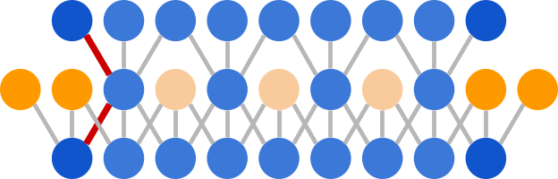

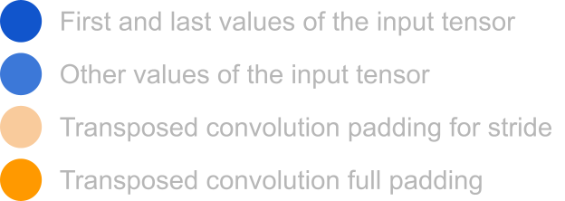

## With half padding (“same” padding)

When a half padding is used, the transposed convolution that allows to produce outputs with the same dimensionality as the encoder inputs must be done with a half padding too.

The figure below shows in this configuration the time alignment between the inputs and outputs of the model is maintained (green lines).

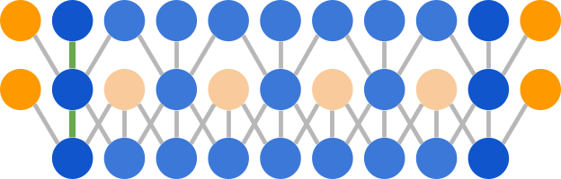

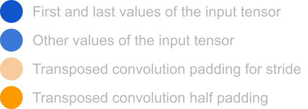

# Streamability

- The RAVE model takes audio chunks as inputs and outputs audio chunks of the same size.
- The RAVE paper shows that it can generate samples at a frequency of 985 kHz on CPU, about 20 times faster than realtime at 48 kHz.
- However, as we have seen, the input audio chunks are padded on both sides before being processed by the model.
- If we consider a stream of audio input, this means that there will be a discontinuity between two consecutive audio chunks.

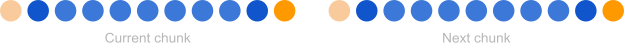

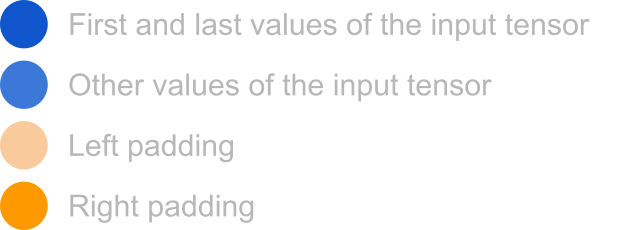

- The [Streamable Neural Audio Synthesis With Non-Causal Convolutions](https://www.google.com/url?q=https://arxiv.org/abs/2204.07064&sa=D&source=editors&ust=1763114472838337&usg=AOvVaw0tCcL4SXTMpvNYjg0TaGHe) paper addresses this issue and the [Streamable Neural Audio Synthesis With Non-Causal Convolutions](https://www.google.com/url?q=https://docs.google.com/document/u/0/d/1QT2NOUo5dCNezgzxttuNtateXHGIQBJscV_ES-FmIQM/edit&sa=D&source=editors&ust=1763114472838502&usg=AOvVaw2SMePyXrIV1raJ-maGrUIw) post dives into it.

# Sources

## RAVE model

- [RAVE: A variational autoencoder for fast and high-quality neural audio synthesis](https://www.google.com/url?q=https://arxiv.org/abs/2111.05011&sa=D&source=editors&ust=1763114472838818&usg=AOvVaw20Ie_XVUlqp1AQn8LO44un)

### Spectral distance

- [DDSP: Differentiable Digital Signal Processing](https://www.google.com/url?q=https://arxiv.org/abs/2001.04643&sa=D&source=editors&ust=1763114472838984&usg=AOvVaw03DWHi9ECawLnnKXuggGcV)

### Feature matching loss

- [MelGAN: Generative Adversarial Networks for Conditional Waveform Synthesis](https://www.google.com/url?q=https://arxiv.org/abs/1910.06711&sa=D&source=editors&ust=1763114472839169&usg=AOvVaw3SsYgSa-b6PshkamJAbl2V)

### Other

- [Generative Adversarial Networks](https://www.google.com/url?q=https://arxiv.org/abs/1406.2661&sa=D&source=editors&ust=1763114472839303&usg=AOvVaw0V4X7OsSqCD19AZw782uw8)

## Dilated convolutions

[https://medium.com/data-science/types-of-convolutions-in-deep-learning-717013397f4d](https://www.google.com/url?q=https://medium.com/data-science/types-of-convolutions-in-deep-learning-717013397f4d&sa=D&source=editors&ust=1763114472839515&usg=AOvVaw1B6Hp9yxK692R8CiEpmiWc)

[https://medium.com/@akp83540/dilation-rate-in-a-convolution-operation-a7143e437654](https://www.google.com/url?q=https://medium.com/@akp83540/dilation-rate-in-a-convolution-operation-a7143e437654&sa=D&source=editors&ust=1763114472839677&usg=AOvVaw3w5JjSpCMdZCn1Z25p7T7C)